# R Code for Case Study on Ensemble Classifiers

##### This notebook contains the code that produces the results in the case study report

##### [Download Data Here](https://www.kaggle.com/ludobenistant/hr-analytics)

Read in the data file and display the top six rows:

```r
dat <- read.csv('HR_comma_sep.csv')
head(dat)
```

|  | satisfaction_level | last_evaluation | number_project | average_montly_hours | time_spend_company | Work_accident | left | promotion_last_5years | sales | salary |
| --- | --- | --- | --- | --- | --- | --- | --- | --- | --- | --- |
| 1 | 0.38 | 0.53 | 2 | 157 | 3 | 0 | 1 | 0 | sales | low |
| 2 | 0.80 | 0.86 | 5 | 262 | 6 | 0 | 1 | 0 | sales | medium |
| 3 | 0.11 | 0.88 | 7 | 272 | 4 | 0 | 1 | 0 | sales | medium |
| 4 | 0.72 | 0.87 | 5 | 223 | 5 | 0 | 1 | 0 | sales | low |
| 5 | 0.37 | 0.52 | 2 | 159 | 3 | 0 | 1 | 0 | sales | low |
| 6 | 0.41 | 0.50 | 2 | 153 | 3 | 0 | 1 | 0 | sales | low |

#### Data Preparation

Display the summary statistics of each column:

```r
summary(dat)
```

```
 satisfaction_level last_evaluation  number_project  average_montly_hours time_spend_company Work_accident         left
 Min.   :0.0900     Min.   :0.3600   Min.   :2.000   Min.   : 96.0        Min.   : 2.000     Min.   :0.0000   Min.   :0.0000
 1st Qu.:0.4400     1st Qu.:0.5600   1st Qu.:3.000   1st Qu.:156.0        1st Qu.: 3.000     1st Qu.:0.0000   1st Qu.:0.0000
 Median :0.6400     Median :0.7200   Median :4.000   Median :200.0        Median : 3.000     Median :0.0000   Median :0.0000
 Mean   :0.6128     Mean   :0.7161   Mean   :3.803   Mean   :201.1        Mean   : 3.498     Mean   :0.1446   Mean   :0.2381
 3rd Qu.:0.8200     3rd Qu.:0.8700   3rd Qu.:5.000   3rd Qu.:245.0        3rd Qu.: 4.000     3rd Qu.:0.0000   3rd Qu.:0.0000
 Max.   :1.0000     Max.   :1.0000   Max.   :7.000   Max.   :310.0        Max.   :10.000     Max.   :1.0000   Max.   :1.0000

 promotion_last_5years         sales         salary
 Min.   :0.00000       sales      :4140   high  :1237
 1st Qu.:0.00000       technical  :2720   low   :7316
 Median :0.00000       support    :2229   medium:6446
 Mean   :0.02127       IT         :1227
 3rd Qu.:0.00000       product_mng: 902
 Max.   :1.00000       marketing  : 858
                       (Other)    :2923
```

```r
dat[6:8] <- lapply(dat[6:8], factor)
dat$salary <- ordered(dat$salary, c('low', 'medium', 'high'))
summary(dat)
```

```
 satisfaction_level last_evaluation  number_project  average_montly_hours time_spend_company Work_accident left
 Min.   :0.0900     Min.   :0.3600   Min.   :2.000   Min.   : 96.0        Min.   : 2.000     0:12830       0:11428
 1st Qu.:0.4400     1st Qu.:0.5600   1st Qu.:3.000   1st Qu.:156.0        1st Qu.: 3.000     1: 2169       1: 3571
 Median :0.6400     Median :0.7200   Median :4.000   Median :200.0        Median : 3.000
 Mean   :0.6128     Mean   :0.7161   Mean   :3.803   Mean   :201.1        Mean   : 3.498
 3rd Qu.:0.8200     3rd Qu.:0.8700   3rd Qu.:5.000   3rd Qu.:245.0        3rd Qu.: 4.000
 Max.   :1.0000     Max.   :1.0000   Max.   :7.000   Max.   :310.0        Max.   :10.000

 promotion_last_5years         sales         salary
 0:14680               sales      :4140   low   :7316
 1:  319               technical  :2720   medium:6446
                       support    :2229   high  :1237
                       IT         :1227
                       product_mng: 902
                       marketing  : 858
                       (Other)    :2923
```

Double check the data type of each column:

```r
lapply(dat, class)
```

```
$satisfaction_level
[1] "numeric"

$last_evaluation
[1] "numeric"

$number_project
[1] "integer"

$average_montly_hours
[1] "integer"

$time_spend_company
[1] "integer"

$Work_accident
[1] "factor"

$left
[1] "factor"

$promotion_last_5years
[1] "factor"

$sales
[1] "factor"

$salary
[1] "ordered" "factor"
```

check the level of left:

```r
levels(dat$left)
```

```
[1] "0" "1"
```

force ‘1’ as the positive level:

```r
dat$left <- factor(dat$left, levels = c('1', '0'))
levels(dat$left)
```

```
[1] "1" "0"
```

Check if there is any missing value in our data:

```r
sum(is.na(dat))
```

```
[1] 0
```

check for redundancy through correlation:

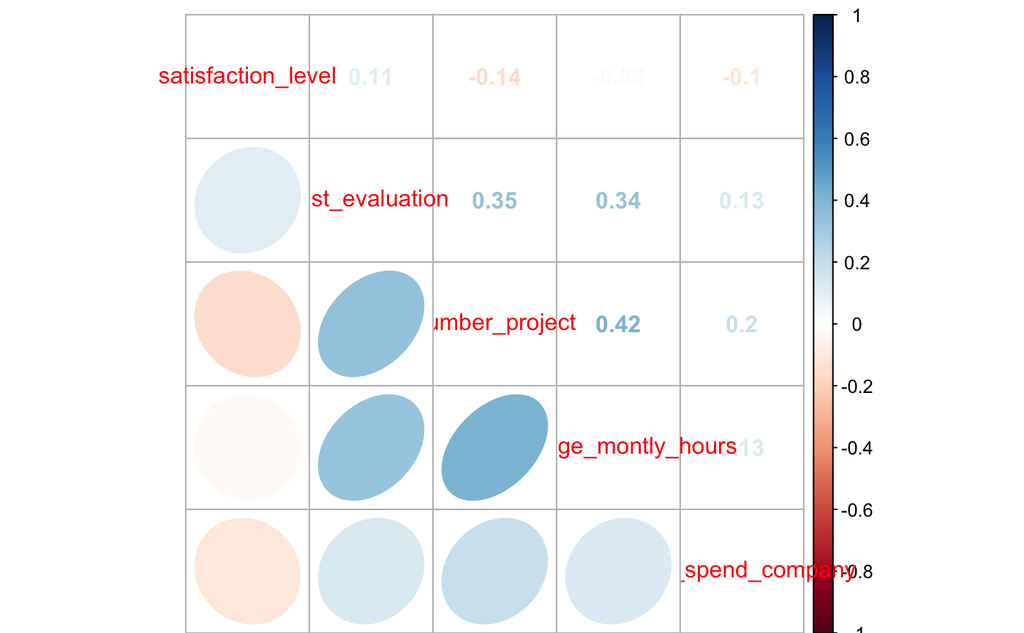

```r
library(corrplot)
var_cor <- cor(dat[,1:5])
corrplot.mixed(var_cor, upper = 'number', lower='ellipse')
```

plot categorical, binary and ordinal data:

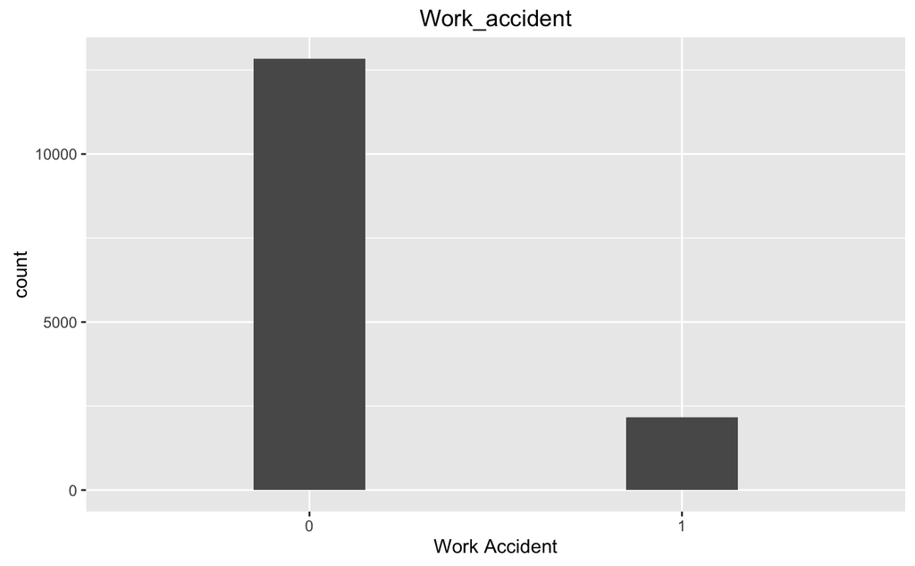

```r
library(ggplot2)
par(mfrow=c(3,1))
ggplot(dat, aes(factor(dat$Work_accident))) + geom_bar(width = 0.3) +
          labs(list(x='Work Accident', title="Work_accident"))
```

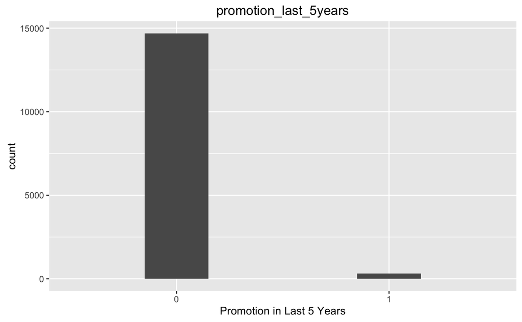

```r
ggplot(dat, aes(factor(dat$promotion_last_5years))) + geom_bar(width = 0.3) +
          labs(list(x='Promotion in Last 5 Years', title="promotion_last_5years"))
```

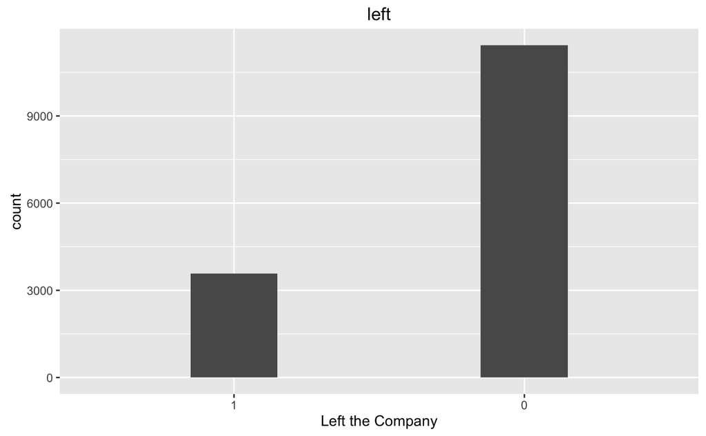

```r
ggplot(dat, aes(factor(dat$left))) + geom_bar(width = 0.3) +
          labs(list(x='Left the Company', title="left"))
```

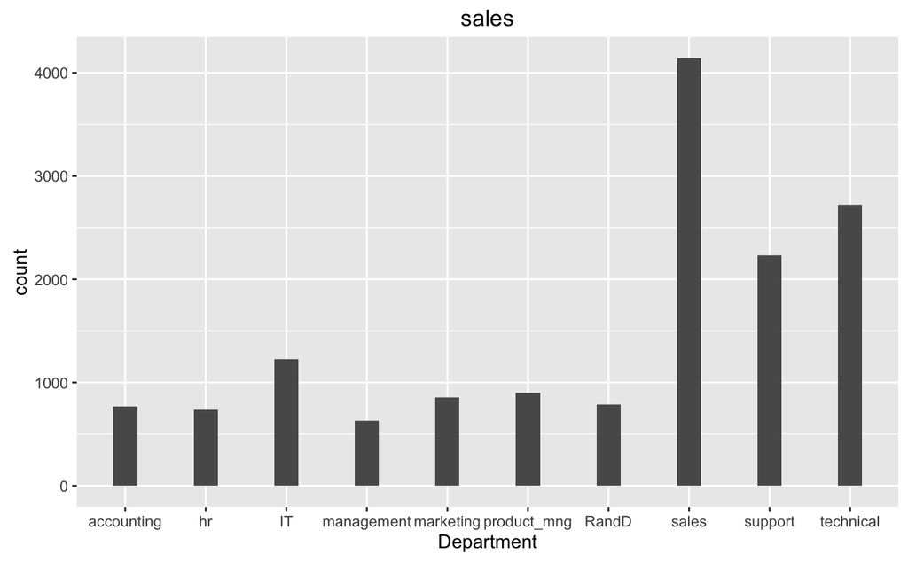

```r
ggplot(dat, aes(factor(dat$sales))) + geom_bar(width = 0.3) +
          labs(list(x='Department', title="sales"))
```

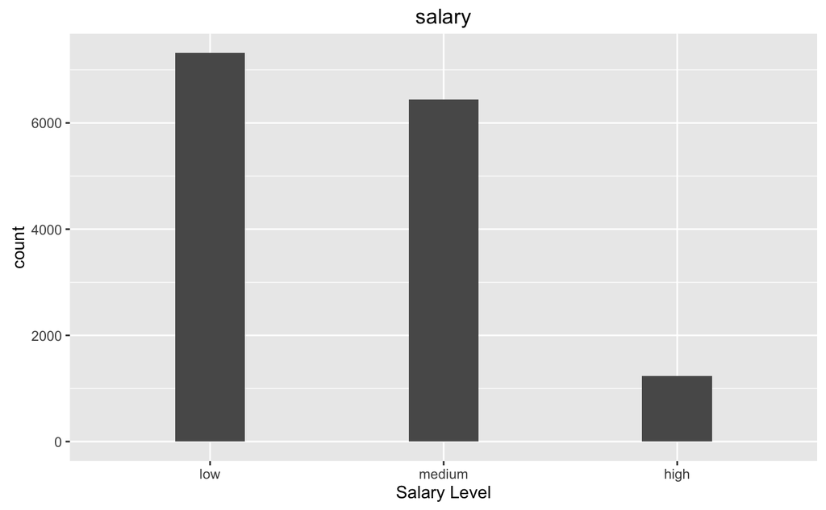

```r
ggplot(dat, aes(factor(dat$salary))) + geom_bar(width = 0.3) +
          labs(list(x='Salary Level', title="salary"))
```

As shown above, there is no missing value in the dataset. After converting variables into proper data types, we need to replace categorical variables with dummy varaibles. However, it will make more sense to conduct preliminary analysis with these variables as factors. So, the dummy variables will be created after preliminary analysis and before applying ML algorihtms.

#### Preliminary Analysis

See report for discussion of this section

min-max normalization function

```r
min_max_norm <- function(attr){
  mi <- min(attr)
  ma <- max(attr)
  return((attr-mi)/(ma-mi))
}
```

Cross-tabluation and bar graph visualization of salary and sales:

```r
as.data.frame.matrix(table(dat$salary, dat$sales))
```

|  | accounting | hr | IT | management | marketing | product_mng | RandD | sales | support | technical |
| --- | --- | --- | --- | --- | --- | --- | --- | --- | --- | --- |
| low | 358 | 335 | 609 | 180 | 402 | 451 | 364 | 2099 | 1146 | 1372 |
| medium | 335 | 359 | 535 | 225 | 376 | 383 | 372 | 1772 | 942 | 1147 |
| high | 74 | 45 | 83 | 225 | 80 | 68 | 51 | 269 | 141 | 201 |

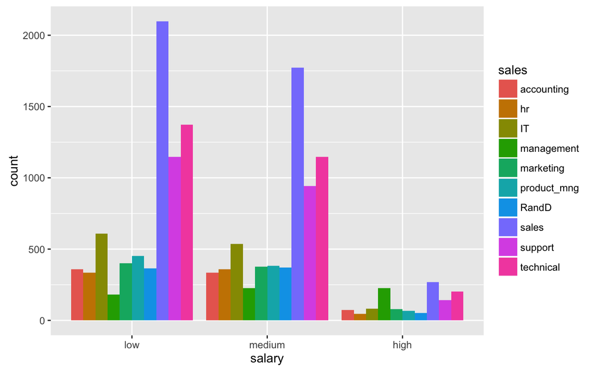

```r
ggplot(dat, aes(salary)) + geom_bar(aes(fill=sales), position="dodge") + scale_fill_hue(l=60)
```

Cross-tabluation of salary and promotion_last_5years and then calculate the percentage:

```r
temp <- as.data.frame.matrix(table(dat$salary, dat$promotion_last_5years))
for(i in 1:3){
  temp[i,] <- temp[i,]/sum(temp[i,])
}
temp
```

|  | 0 | 1 |
| --- | --- | --- |
| low | 0.9909787 | 0.009021323 |
| medium | 0.9719206 | 0.028079429 |
| high | 0.9417947 | 0.058205335 |

Cross-tabluation of left and work_accident and then calculate the percentage:

```r
temp <- as.data.frame.matrix(table(dat$left, dat$Work_accident))
for(i in 1:2){
  temp[,i] <- temp[,i]/sum(temp[,i])
}
temp
```

|  | 0 | 1 |
| --- | --- | --- |
| 1 | 0.2651598 | 0.07791609 |
| 0 | 0.7348402 | 0.92208391 |

```r
temp <- as.data.frame.matrix(table(dat$salary, dat$time_spend_company))
for (i in 1:3){
  temp[i,] <- temp[i,]/sum(temp[i,])
}
temp
```

|  | 2 | 3 | 4 | 5 | 6 | 7 | 8 | 10 |
| --- | --- | --- | --- | --- | --- | --- | --- | --- |
| low | 0.2087206 | 0.4380809 | 0.1776927 | 0.10921268 | 0.04551668 | 0.004920722 | 0.008201203 | 0.007654456 |
| medium | 0.2193608 | 0.4216568 | 0.1681663 | 0.09432206 | 0.05119454 | 0.017685386 | 0.013031337 | 0.014582687 |
| high | 0.2449475 | 0.4203719 | 0.1398545 | 0.05335489 | 0.04446241 | 0.030719483 | 0.014551334 | 0.051738076 |

[figure not shown]

```r
ggplot(dat, aes(salary)) + geom_bar(aes(fill=time_spend_company), position="dodge") + scale_fill_hue(l=60)
```

Cross-tabluation of left and time_spend_company:

```r
temp <- as.data.frame.matrix(table(dat$left, dat$time_spend_company))
for (i in 1:3){
  temp[i,] <- temp[i,]/sum(temp[i,])
}
temp
```

|  | 2 | 3 | 4 | 5 | 6 | 7 | 8 | 10 |
| --- | --- | --- | --- | --- | --- | --- | --- | --- |
| 1 | 0.01484178 | 0.4441333 | 0.2492299 | 0.2332680 | 0.05852702 | 0.00000000 | 0.00000000 | 0.00000000 |
| 0 | 0.27922646 | 0.4250088 | 0.1458698 | 0.0560028 | 0.04453973 | 0.01645082 | 0.01417571 | 0.01872594 |
| NA | NA | NA | NA | NA | NA | NA | NA | NA |

density plot of monthly hour, and by left and sales variables

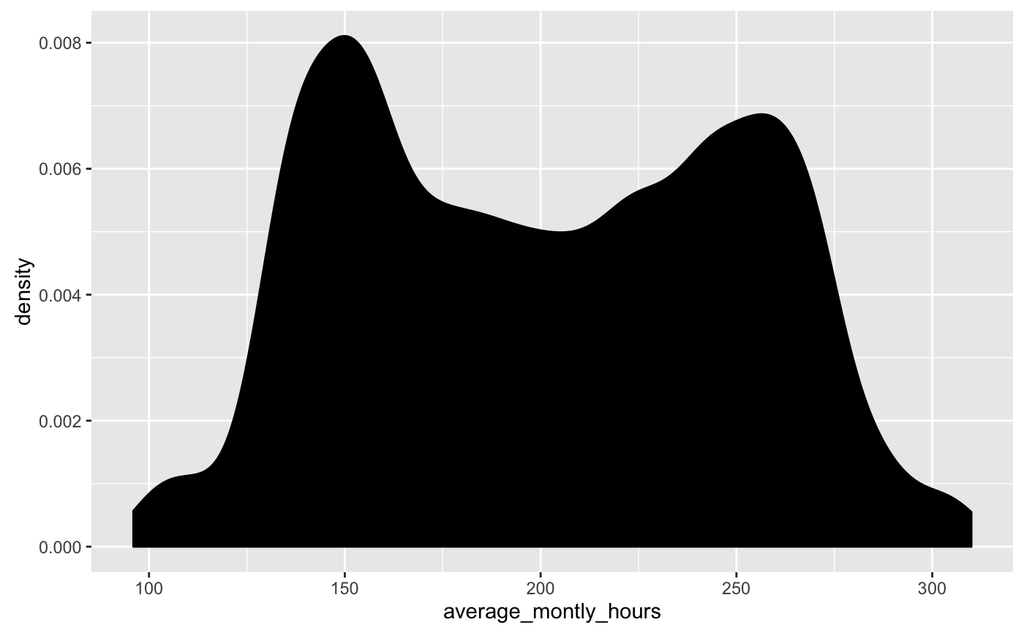

```r
ggplot(dat, aes(average_montly_hours)) + geom_density(fill="black")
```

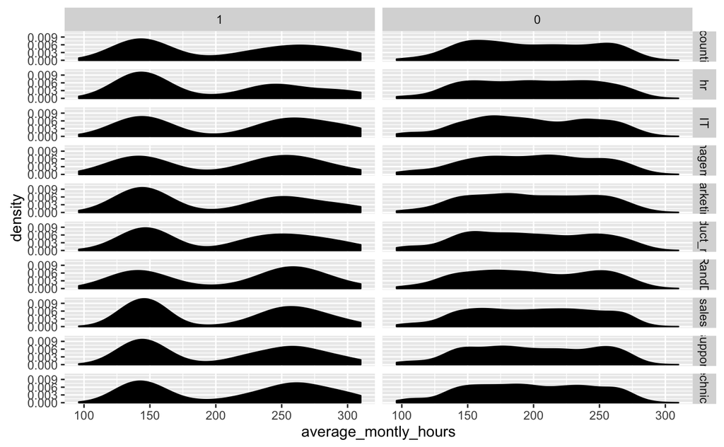

```r
ggplot(dat, aes(average_montly_hours)) + geom_density(fill="black") + facet_grid(sales ~ left)
```

cross tabulation of left and number_project

```r
temp <- as.data.frame.matrix(table(dat$left, dat$number_project))
for (i in 1:2){
  temp[i,] <- temp[i,]/sum(temp[i,])
}
temp
```

|  | 2 | 3 | 4 | 5 | 6 | 7 |
| --- | --- | --- | --- | --- | --- | --- |
| 1 | 0.43881266 | 0.02016242 | 0.1145337 | 0.1713806 | 0.18342201 | 0.0716886 |
| 0 | 0.07184109 | 0.34852993 | 0.3461673 | 0.1880469 | 0.04541477 | 0.0000000 |

realtionship among last_evaluation, time_spend_company and left

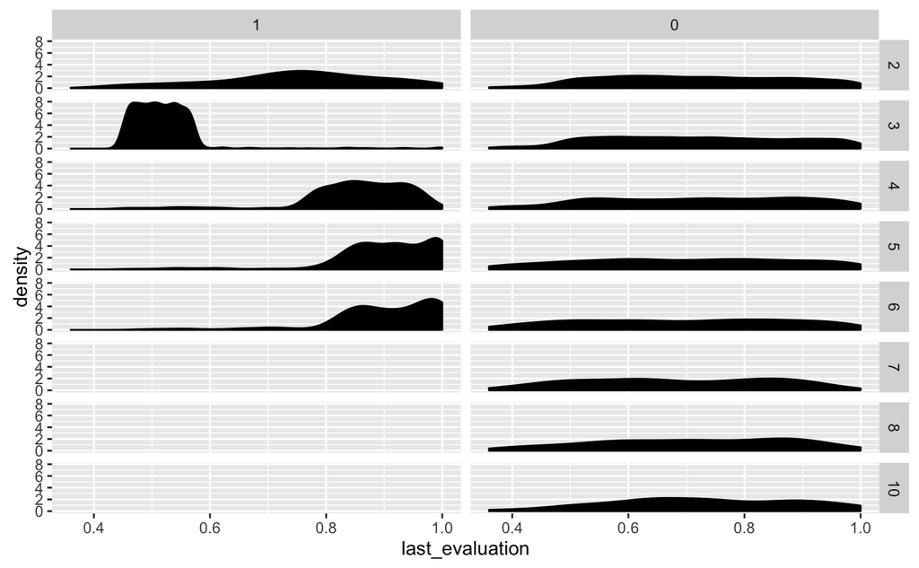

```r
ggplot(dat, aes(last_evaluation)) + geom_density(fill="black") + facet_grid(time_spend_company ~ left)
```

relationship between satisfaction_level, department and left

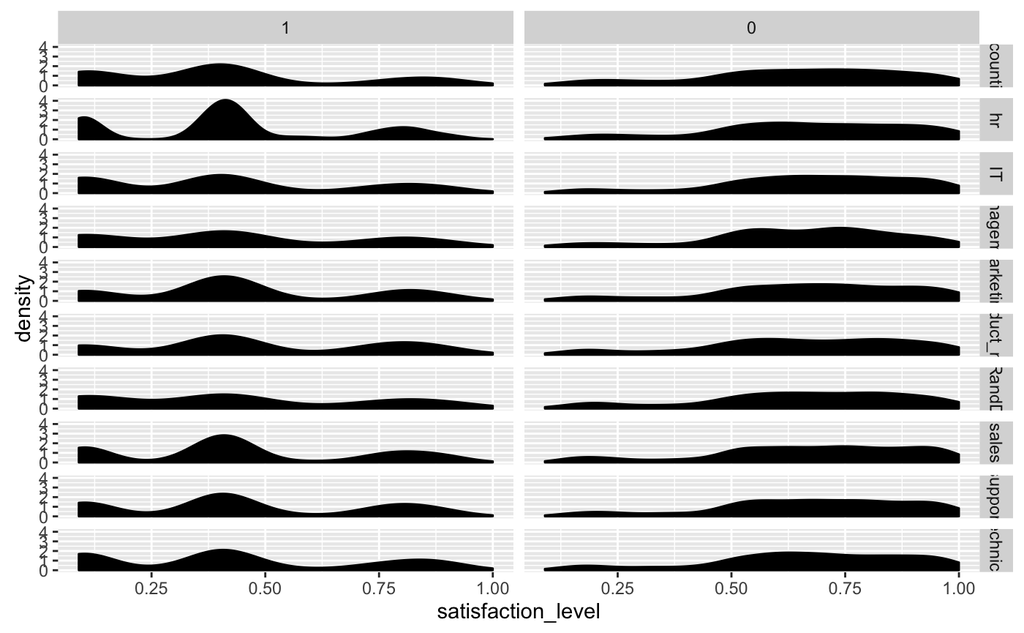

```r
ggplot(dat, aes(satisfaction_level)) + geom_density(fill="black") + facet_grid(sales ~ left)
```

#### Data transformation

Converting dummies

```r
head(as.data.frame.matrix(model.matrix(~Work_accident+promotion_last_5years+sales-1, dat)))
```

|  | Work_accident0 | Work_accident1 | promotion_last_5years1 | saleshr | salesIT | salesmanagement | salesmarketing | salesproduct_mng | salesRandD | salessales | salessupport | salestechnical |
| --- | --- | --- | --- | --- | --- | --- | --- | --- | --- | --- | --- | --- |
| 1 | 1 | 0 | 0 | 0 | 0 | 0 | 0 | 0 | 0 | 1 | 0 | 0 |
| 2 | 1 | 0 | 0 | 0 | 0 | 0 | 0 | 0 | 0 | 1 | 0 | 0 |
| 3 | 1 | 0 | 0 | 0 | 0 | 0 | 0 | 0 | 0 | 1 | 0 | 0 |
| 4 | 1 | 0 | 0 | 0 | 0 | 0 | 0 | 0 | 0 | 1 | 0 | 0 |
| 5 | 1 | 0 | 0 | 0 | 0 | 0 | 0 | 0 | 0 | 1 | 0 | 0 |
| 6 | 1 | 0 | 0 | 0 | 0 | 0 | 0 | 0 | 0 | 1 | 0 | 0 |

concatenate with the dat dataframe

```r
dums <- as.data.frame.matrix(model.matrix(~Work_accident+promotion_last_5years+sales-1, dat))
salaryLow <- as.data.frame(ifelse(dat$salary=='low', 1, 0))
colnames(salaryLow) <- 'salaryLow'
salaryMed <- as.data.frame(ifelse(dat$salary=='medium', 1, 0))
colnames(salaryMed) <- 'salaryMed'
salaryHigh <- as.data.frame(ifelse(dat$salary=='high', 1, 0))
colnames(salaryHigh) <- 'salaryHigh'
dat <- cbind(dat, dums, salaryLow, salaryMed, salaryHigh)
dat[,c('Work_accident','promotion_last_5years','sales', 'salary')] <- NULL
left <- dat$left
dat$left <- NULL
dat$left <- left
head(dat)
```

|  | satisfaction_level | last_evaluation | number_project | average_montly_hours | time_spend_company | Work_accident0 | Work_accident1 | promotion_last_5years1 | saleshr | salesIT | salesmanagement | salesmarketing | salesproduct_mng | salesRandD | salessales | salessupport | salestechnical | salaryLow | salaryMed | salaryHigh | left |
| --- | --- | --- | --- | --- | --- | --- | --- | --- | --- | --- | --- | --- | --- | --- | --- | --- | --- | --- | --- | --- | --- |
| 1 | 0.38 | 0.53 | 2 | 157 | 3 | 1 | 0 | 0 | 0 | 0 | 0 | 0 | 0 | 0 | 1 | 0 | 0 | 1 | 0 | 0 | 1 |
| 2 | 0.80 | 0.86 | 5 | 262 | 6 | 1 | 0 | 0 | 0 | 0 | 0 | 0 | 0 | 0 | 1 | 0 | 0 | 0 | 1 | 0 | 1 |
| 3 | 0.11 | 0.88 | 7 | 272 | 4 | 1 | 0 | 0 | 0 | 0 | 0 | 0 | 0 | 0 | 1 | 0 | 0 | 0 | 1 | 0 | 1 |
| 4 | 0.72 | 0.87 | 5 | 223 | 5 | 1 | 0 | 0 | 0 | 0 | 0 | 0 | 0 | 0 | 1 | 0 | 0 | 1 | 0 | 0 | 1 |
| 5 | 0.37 | 0.52 | 2 | 159 | 3 | 1 | 0 | 0 | 0 | 0 | 0 | 0 | 0 | 0 | 1 | 0 | 0 | 1 | 0 | 0 | 1 |
| 6 | 0.41 | 0.50 | 2 | 153 | 3 | 1 | 0 | 0 | 0 | 0 | 0 | 0 | 0 | 0 | 1 | 0 | 0 | 1 | 0 | 0 | 1 |

#### Model fitting

Distribution of class labels (count & probability):

```r
table(dat$left)
```

```
    1     0
 3571 11428
```

```r
prop.table(table(dat$left))
```

```
        1         0
0.2380825 0.7619175
```

Deal with unbalanced data first:

```r
library(DMwR)
library(caret)
set.seed(1234)
ind <- sample(2, nrow(dat), replace=TRUE, prob=c(0.8, 0.2))
train <- dat[ind==1,]
test <- dat[ind==2,]
table(train$left)
```

```
   1    0
2849 9136
```

```r
prop.table(table(train$left))
```

```
        1         0
0.2377138 0.7622862
```

```r
train <- SMOTE(left~., train, perc.over= 50, perc.under = 300)
table(train$left)
```

```
   1    0
4273 4272
```

Decision Tree: training with 5-fold CV

```r
ctrl <- trainControl(method = "cv", number = 5)
model.tree <- train(left~., data = train, method='rpart', trControl = ctrl)
```

Logistic Regression: training with 5-fold CV

```r
model.logistic <- train(left~., data = train, method='glm', trControl = ctrl)
```

[output not shown]

```r
test.logistic <- predict(model.logistic, test)
```

```
prediction from a rank-deficient fit may be misleading
```

```r
confusionMatrix(test.logistic, test$left)
```

```
Confusion Matrix and Statistics

          Reference
Prediction    1    0
         1  556  568
         0  166 1724

               Accuracy : 0.7565
                 95% CI : (0.7407, 0.7717)
    No Information Rate : 0.7605
    P-Value [Acc > NIR] : 0.7041

                  Kappa : 0.4386
 Mcnemar's Test P-Value : <2e-16

            Sensitivity : 0.7701
            Specificity : 0.7522
         Pos Pred Value : 0.4947
         Neg Pred Value : 0.9122
             Prevalence : 0.2395
         Detection Rate : 0.1845
   Detection Prevalence : 0.3729
      Balanced Accuracy : 0.7611

       'Positive' Class : 1
```

```r
model.logistic$finalModel
```

```
Call:  NULL

Coefficients:
           (Intercept)      satisfaction_level         last_evaluation          number_project    average_montly_hours
              2.165091                4.549365               -1.188177                0.401184               -0.004887
    time_spend_company          Work_accident0          Work_accident1  promotion_last_5years1                 saleshr
             -0.431615               -1.549582                      NA                1.751426               -0.029941
               salesIT         salesmanagement          salesmarketing        salesproduct_mng              salesRandD
              0.441621                0.761221                0.083053                0.296837                0.690527
            salessales            salessupport          salestechnical               salaryLow               salaryMed
              0.257308                0.026141                0.128196               -1.893700               -1.446135
            salaryHigh
                    NA

Degrees of Freedom: 8544 Total (i.e. Null);  8526 Residual
Null Deviance:      11850
Residual Deviance: 8863     AIC: 8901
```

##### Ensemble Models

Random Forest: training with 5-fold CV (takes time to train and find the best model)

```r
model.rf <- train(left~., data = train, method='rf', trControl = ctrl)
test.rf <- predict(model.rf, test)
confusionMatrix(test.rf, test$left)
```

```
Confusion Matrix and Statistics

          Reference
Prediction    1    0
         1  708   20
         0   14 2272

               Accuracy : 0.9887
                 95% CI : (0.9843, 0.9922)
    No Information Rate : 0.7605
    P-Value [Acc > NIR] : <2e-16

                  Kappa : 0.9691
 Mcnemar's Test P-Value : 0.3912

            Sensitivity : 0.9806
            Specificity : 0.9913
         Pos Pred Value : 0.9725
         Neg Pred Value : 0.9939
             Prevalence : 0.2395
         Detection Rate : 0.2349
   Detection Prevalence : 0.2415
      Balanced Accuracy : 0.9859

       'Positive' Class : 1
```

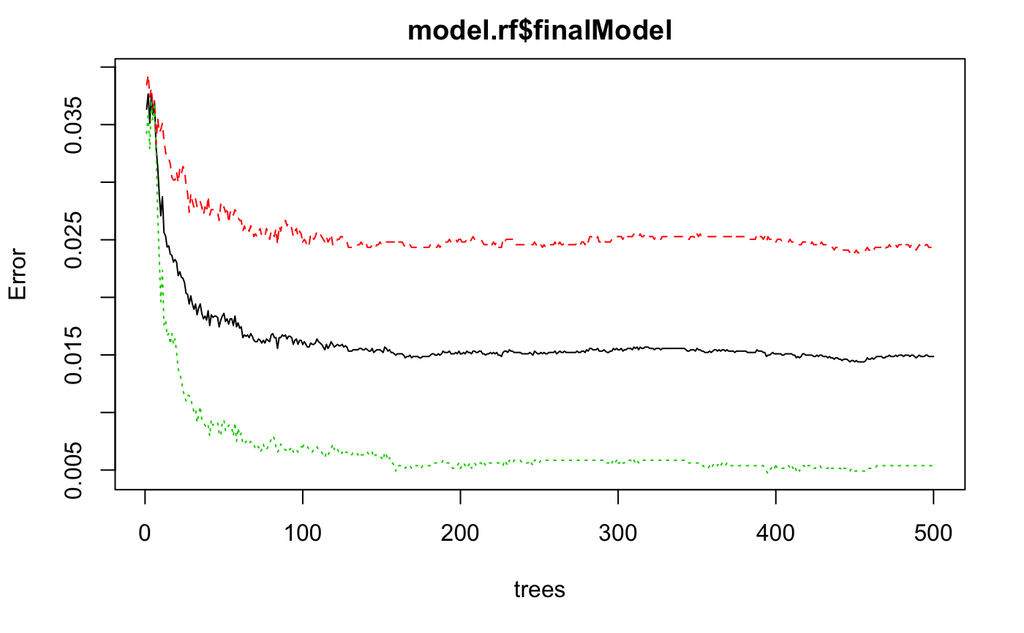

```r
plot(model.rf$finalModel)
```

```r
model.rf$finalModel$importance
```

```
                       MeanDecreaseGini
satisfaction_level          1419.087850
last_evaluation              476.276682
number_project               501.728292
average_montly_hours         526.071580
time_spend_company          1209.519567
Work_accident0                 6.539421
Work_accident1                 7.211869
promotion_last_5years1         4.444539
saleshr                       10.726332
salesIT                        7.352289
salesmanagement                5.992262
salesmarketing                 4.361829
salesproduct_mng               2.521014
salesRandD                     4.649052
salessales                    14.697205
salessupport                  13.984698
salestechnical                15.833466
salaryLow                     18.080855
salaryMed                     12.416272
salaryHigh                     8.899428
```

boosted logistic regression:

```r
model.ada <- train(left~., data = train, method='LogitBoost')
```

ROC curves of all models

```r
library(ROCR)
tree.pred <- prediction(predict(model.tree$finalModel, test, type='prob')[,1], test$left)
tree.perf <- performance(tree.pred, "tpr", "fpr")
logit.pred <- prediction(predict(model.logistic$finalModel, test, type='response'), test$left)
```

```
prediction from a rank-deficient fit may be misleading
```

```r
logit.perf <- performance(logit.pred, "tpr", "fpr")
rf.pred <- prediction(as.numeric(predict(model.rf$finalModel, test)), as.numeric(test$left))
rf.perf <- performance(rf.pred, "tpr", "fpr")
bglm.pred <- prediction(as.numeric(predict(model.ada$finalModel, test)), as.numeric(test$left))
bglm.perf <- performance(bglm.pred, "tpr", "fpr")
plot(tree.perf, col = 'red', lty=1)
plot(logit.perf, add = TRUE, col = 'blue', lty=2)
```

```r
plot(rf.perf, add=TRUE, col='green', lty=3)
plot(bglm.perf, add=TRUE, col='purple', lty=4)
```

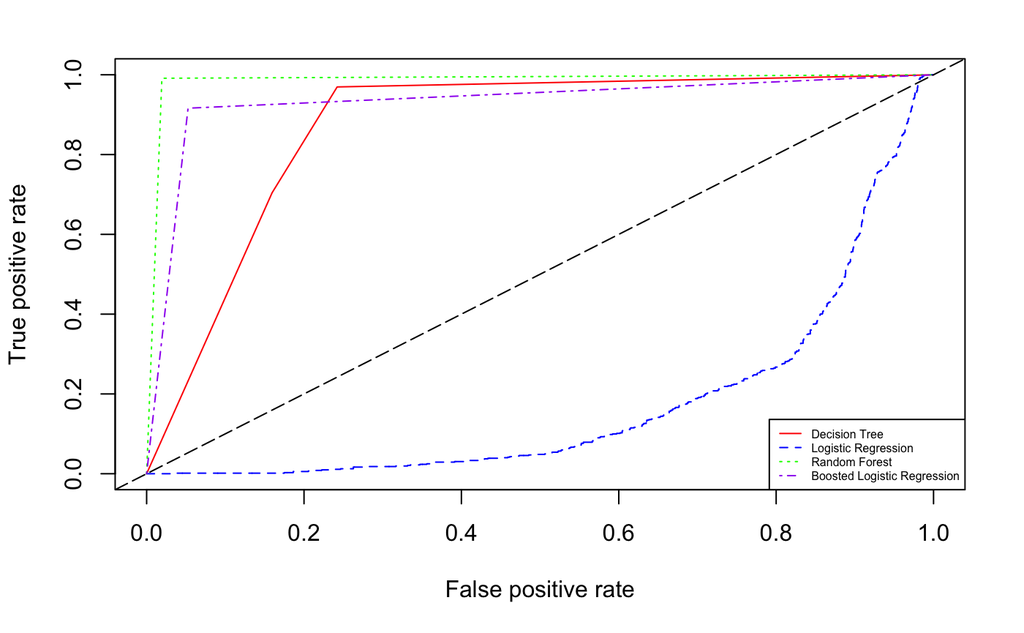

```r
abline(0, 1, lty = 5)
legend('bottomright',
       legend=c('Decision Tree', 'Logistic Regression', 'Random Forest', 'Boosted Logistic Regression'),
       col = c('red', 'blue', 'green', 'purple'),
       lty = 1:4,
       cex = 0.5)
```